...

```python
#Code to load necessary python modules
import pandas as pd
import numpy as np
import matplotlib.pyplot as plt
from scipy.stats import linregress
from IPython.display import display, Markdown, HTML
from scipy.stats import ttest_ind
from scipy import stats
from scipy.stats import spearmanr

# function to display figures with formatting and caption
def display_figure(fig, fig_id, caption, w=0.6, fs=12):
    import io
    import base64
    plt.rcParams['figure.dpi'] = 300
    plt.rcParams['savefig.dpi'] = 300
    pic_IObytes = io.BytesIO()

    # set fontsize for title and labels
    for ax in fig.axes:
        text_items = [ax.title, ax.xaxis.label, ax.yaxis.label]
        if ax.get_legend() is not None:
            text_items = text_items + ax.get_legend().get_texts()
        for item in (text_items + ax.get_xticklabels() + ax.get_yticklabels() ):
            item.set_fontsize(fs)

    plt.savefig(pic_IObytes,  format='png', bbox_inches='tight')
    pic_IObytes.seek(0)
    pic_hash = base64.b64encode(pic_IObytes.read())
    img = f'<img margin="auto" width="{w*100}%" src="data:… {str(pic_hash)[2:-1]}" />'
    caption = f'<figcaption style="text-align: center; font-style: italic;">{caption}</figcaption>'
    display(HTML(f'<br><fig width="100%" id={fig_id}><center>{img}</center> {caption}</fig><br>'))
    plt.close(fig)
```

# Investigating Approximate Number Sensing

### 1. Introduction

The approximate number system(ANS) is an approach that estimates the size of a group without using symbols or linguistics. It has been reported that ANS enables an individual to identify differences in size between groups of things from a young age.

The ANS is connected to competence in mathematics, spatial reasoning, and memory. Mazzocco et al.(2011) were the first to demonstrate that early precision in the Approximate Number System (ANS) measured at preschool predicts mathematics skills in primary school, independent of general IQ. In addition, Wulandari et al.(2021) mention that in solving mathematical problems, pre-service mathematics teachers with strong number sense abilities also exhibit spatial reasoning skills.

Furthermore, previous studies have demonstrated there is a difference between males and females when it comes to cognitive tests. Males performed better in three main spatial ability tasks, including spatial perception, spatial visualization, and mental rotation Weiss et al.(2003). Also, Stoet & Geary(2013) analyzed one decade of data collected by the Programme for International Student Assessment (PISA) and demonstrated generally boys scored higher than girls in mathematics. Memory is quite stable across the genders. In Pauls, Petermann, & Lepach(2013), from participants aged between 16 and 69, females performed better on auditory memory tasks, while males were better at visual episodic and visual working memory tasks.

In our investigation, we first examined whether ANS is related to maths, spatial reasoning, or memory skills. Next, we examined whether the difference is significant between males and females across the four tests. Our investigation is motivated by a desire to understand how various cognitive abilities, such as ANS, are interconnected and support skills in mathematics, memory, and spatial reasoning. Insights from this study could shape educational strategies and interventions, especially for young learners, by clarifying which cognitive processes are vital for the growth of these skills. Additionally, we aim to explore possible gender differences in cognitive abilities to promote educational fairness. Recognizing these disparities is key to creating more inclusive and tailored teaching approaches.

## 2. Methods

### 2.1 Overview

#### 2.1.1 Literature Review

We initiated a detailed review of existing research in the field of ANS and cognitive tests. This review will serve to establish foundational knowledge, identify gaps in current understanding, and reference significant prior work, particularly studies related to our hypotheses.

#### 2.1.2 Sample

We targeted students enrolled in the “Coding for Bioscience Research” module. Next, we expanded the sample to include students from relevant but diverse disciplines, both within and outside the primary module. We ensured a broad demographic representation, including different nationalities, geographical locations, educational backgrounds, family members, and friends, to enhance the generalizability of our findings.

We gathered data on gender, average time, and accuracy. Additionally, drinks taken before the tests, academic background, and family influence on their mathematics ability were also recorded for further research into ANS. Those variables will be used to build a linear regression model. In addition, all participants received the same questions in the same sequence, guaranteeing uniformity of test conditions.

Consent for Data Use: Obtain informed consent from participants for the use of their test results in our study, adhering to ethical research standards.

Instruction: Before each test, participants were informed of the purpose and how they were tested

### 2.2 Methodologies

- In the ANS test, the participants were asked to select the side with more dots. The buttons ‘left’ and ‘right’ appeared in the corresponding position (left or right). Participants were given time to see the image (1.5 seconds), to respond (3 seconds), and to relax (1.5 seconds).
- In the maths test, participants were given 20 progressively challenging questions within 3 minutes and 30 seconds. For example, ‘2’ was displayed for 1.5 seconds and then erased, which was followed by displaying ‘+5’ for 1.5 seconds. This assesses memory and mathematical ability under time constraints.
- In the memory test, three tests were shown for 20 seconds. After seeing each grid, participants answered questions like "What color was the square?".
- In the spatial reasoning test, participants had 3 minutes to answer questions about 3D cubes and associated 2D images. The test examined their mental orientation, spatial visualization, and spatial inference abilities.

Further efforts will be worthwhile because if we know whether ANS affects students’ learning, this would be beneficial for teachers and parents, and they can come up with ideas to support the education of children.

## 3. Results and Discussion

In this study, we focused on examining the two hypotheses by applying different statistical analysis methods to the data collected. Extensional research was done to investigate the effect of different drinks on ANS ability as well as the effects of different categories in the ANS test on participants' performance. First, we selected available sample data by merging the sample from all four tests to collect scores in each test.

```python
# read data from 4 test
def process_csv(file_path):
    df = pd.read_csv(file_path)
    df_processed = df.drop_duplicates(subset='user_id', keep='last').reset_index(drop=True)
    return df_processed

df_ans = process_csv('ans_short.csv')
df_math = process_csv('math_short.csv')
df_memory = process_csv('memory_short.csv')
df_spatial = process_csv('spatial_short.csv')
df_analysis = process_csv('ans_analysis.csv')
```

```python
# merge data of 4 tests for score
df_merged = pd.merge(df_ans,df_math, on = 'user_id', how = 'inner', suffixes = ['_ans', '_math'])
df_merged1 = df_merged.drop(columns=['average_time','age_math','gender_math'])
df_merged2 = df_merged1.rename(columns={'age_ans': 'age','gender_ans':'gender'})
df_merged3 = pd.merge(df_spatial, df_memory, on = 'user_id', how = 'inner', suffixes = ['_spatial','_memory'])
df_merged4 = df_merged3.drop(columns=['average_time_spatial','age_spatial','gender_spatial','average_time_memory','age_memory','gender_memory'])
df_result1 = pd.merge(df_merged2, df_merged4, on = 'user_id', how = 'inner', suffixes = ['_spatial','_memory'])
df_result1
```

|  | user_id | age | gender | score_ans | score_math | score_spatial | score_memory |
| --- | --- | --- | --- | --- | --- | --- | --- |
| 0 | VGAT | 21 | female | 73 | 35 | 10 | 33.33 |
| 1 | MCHC | 19 | male | 67 | 65 | 86 | 22.22 |
| 2 | YCBH | 20 | female | 90 | 70 | 75 | 47.78 |
| 3 | CTCT | 21 | female | 63 | 65 | 60 | 50.00 |
| 4 | FZHF | 19 | male | 80 | 80 | 86 | 23.33 |
| 5 | RHJM | 20 | male | 83 | 95 | 60 | 58.89 |
| 6 | HAHA | 20 | male | 83 | 80 | 67 | 51.11 |
| 7 | FWNO | 20 | male | 73 | 60 | 50 | 51.11 |
| 8 | ABAB | 20 | male | 83 | 70 | 78 | 37.78 |
| 9 | WWWW | 18 | female | 77 | 65 | 80 | 16.67 |
| 10 | KKXX | 20 | male | 67 | 45 | 60 | 64.44 |
| 11 | CNDB | 18 | male | 53 | 70 | 14 | 20.00 |
| 12 | FGFG | 20 | male | 57 | 80 | 67 | 70.00 |
| 13 | TRLO | 20 | male | 47 | 50 | 100 | 20.00 |
| 14 | XTTR | 21 | male | 60 | 40 | 100 | 17.78 |
| 15 | WYCM | 25 | female | 67 | 60 | 100 | 60.00 |
| 16 | PENG | 22 | male | 80 | 95 | 22 | 93.33 |
| 17 | TTTT | 20 | male | 83 | 90 | 86 | 40.00 |
| 18 | ZQTC | 54 | female | 63 | 55 | 50 | 29.00 |
| 19 | QQQQ | 20 | male | 63 | 60 | 60 | 50.00 |
| 20 | DXEW | 20 | male | 77 | 95 | 86 | 22.40 |

Similarly, merging method was required to collect the average time of "overlapped" users.

```python
#merge data of average react time of 3 tests
# math test data is not recorded, so math is not included
df_merged5 = pd.merge(df_ans, df_spatial, on = 'user_id', how = 'inner', suffixes = ['_ans','_spatial'])
df_merged6 = pd.merge(df_merged5, df_memory, on = 'user_id', how = 'inner', suffixes = ['_ans','_spatial','_memory'])
df_merged7 = df_merged6.drop(columns=['score_ans','score_spatial','score','age_spatial','gender_spatial','age','gender'])
df_result_time = df_merged7.rename(columns={'age_ans': 'age','gender_ans':'gender','average_time':'average_time_memory'})
df_result_time
```

|  | user_id | age | gender | average_time_ans | average_time_spatial | average_time_memory |
| --- | --- | --- | --- | --- | --- | --- |
| 0 | VGAT | 21 | female | 1.152688 | 9.517158 | 3.38 |
| 1 | MCHC | 19 | male | 1.262874 | 33.318160 | 6.40 |
| 2 | CYNT | 20 | female | 0.920982 | 36.899066 | 3.84 |
| 3 | YCBH | 20 | female | 1.213476 | 48.749018 | 4.16 |
| 4 | CTCT | 21 | female | 0.942580 | 38.208501 | 4.15 |
| 5 | FZHF | 19 | male | 1.027113 | 26.838768 | 3.68 |
| 6 | RHJM | 20 | male | 1.273456 | 39.294845 | 4.57 |
| 7 | HAHA | 20 | male | 0.781165 | 23.177306 | 1.54 |
| 8 | FWNO | 20 | male | 1.191107 | 32.928919 | 4.85 |
| 9 | ABAB | 20 | male | 0.802164 | 20.391182 | 3.02 |
| 10 | WWWW | 18 | female | 1.535741 | 36.686562 | 6.09 |
| 11 | KKXX | 20 | male | 1.781928 | 45.310287 | 5.26 |
| 12 | CNDB | 18 | male | 1.445827 | 26.356975 | 5.60 |
| 13 | FGFG | 20 | male | 0.798631 | 31.070679 | 4.37 |
| 14 | TRLO | 20 | male | 1.843662 | 51.725601 | 5.60 |
| 15 | XTTR | 21 | male | 1.770986 | 45.623591 | 5.76 |
| 16 | XIED | 20 | male | 0.884942 | 9.334219 | 7.22 |
| 17 | WYCM | 25 | female | 1.649546 | 106.219078 | 6.70 |
| 18 | PENG | 22 | male | 0.727761 | 23.395577 | 3.76 |
| 19 | TTTT | 20 | male | 1.099497 | 29.215119 | 5.67 |
| 20 | ZQTC | 54 | female | 1.721726 | 45.362012 | 5.80 |
| 21 | QQQQ | 20 | male | 1.004333 | 42.108550 | 6.23 |
| 22 | DXEW | 20 | male | 0.916835 | 26.502665 | 5.60 |

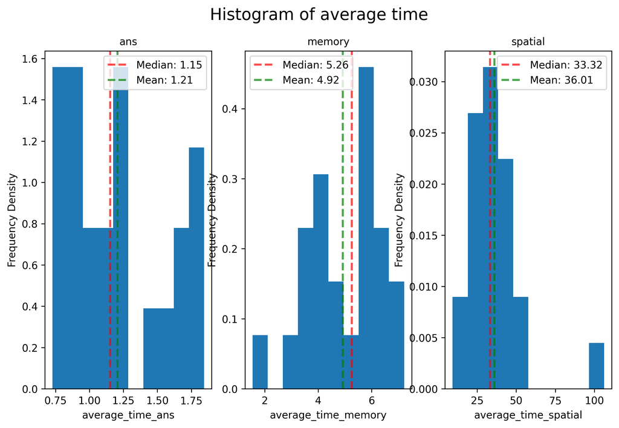

Figure1: Histogram plots of average time in ANS, memory, and spatial reasoning tests

```python
def plot_histogram_subplot(column_name, subplot_index, subplot_title):

    plt.hist(df_result_time[column_name], density=True, bins=10)
    plt.title(subplot_title)
    plt.xlabel(column_name)
    plt.ylabel('Frequency Density')

    # Add median and mean to the plot
    median_val = df_result_time[column_name].median()
    mean_val = df_result_time[column_name].mean()

    plt.axvline(median_val, color='red', alpha=0.7, linestyle='dashed', linewidth=2, label=f'Median: {median_val:.2f}')
    plt.axvline(mean_val, color='green', alpha=0.7, linestyle='dashed', linewidth=2, label=f'Mean: {mean_val:.2f}')
    plt.legend()

fig = plt.figure(figsize=(10, 6))
fig.suptitle('Histogram of average time', fontsize=16)

plt.subplot(1, 3, 1)
plot_histogram_subplot('average_time_ans', 1, 'ans')
plt.subplot(1, 3, 2)
plot_histogram_subplot('average_time_memory', 2, 'memory')
plt.subplot(1, 3, 3)
plot_histogram_subplot('average_time_spatial', 3, 'spatial')

# To display figure with caption
caption = "Figure1: Histogram plots of average time in ANS, memory, and spatial reasoning tests"

display_figure(fig, "fig1", caption, 0.8, 10)
```

### 3.1 Hypothesis A: Is ANS related to the other 3 tests, maths, memory and spatial?

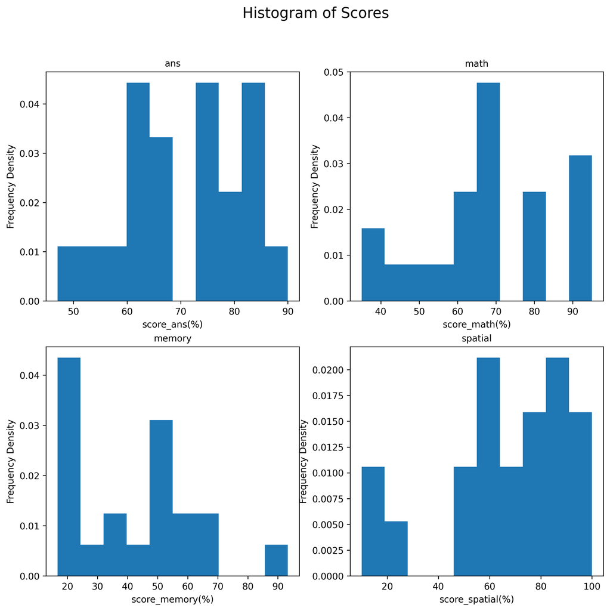

Figure2: Histogram plots of marks(accuracy percentage *100) of the four tests

```python
#hypothesis A
def plot_histogram_subplot(column_name, subplot_index, subplot_title):
    #plot bars
    plt.subplot(2, 2, subplot_index)
    plt.hist(df_result1[column_name], density=True, bins=10)
    plt.title(subplot_title)
    plt.xlabel(f'{column_name}(%)')
    plt.ylabel('Frequency Density')

#set title and figure size
fig = plt.figure(figsize=(11, 10))
fig.suptitle('Histogram of Scores', fontsize=16)

#plot subplots
plot_histogram_subplot('score_ans', 1, 'ans')
plot_histogram_subplot('score_math', 2, 'math')
plot_histogram_subplot('score_memory', 3, 'memory')
plot_histogram_subplot('score_spatial', 4, 'spatial')

# To display figure with caption
caption = "Figure2: Histogram plots of marks(accuracy percentage *100) of the four tests"

display_figure(fig, "fig2", caption, 0.8, 10)
```

Scatter graphs (Figure 3) helped explore relationships between two variables, with the option of assessing correlations using the R-squared-value. In this analysis, we separately compared scores from three tests with those from the ANS test. Greater closeness to the line suggests a higher likelihood of correlation. In our investigation, the R-squared value suggests that a 26.1% variance of scores on the math test, a 5.1% variance of scores on the memory test and a 0.0% variance of scores on the spatial test explain the variance of the ANS test. (i.e. how the dots in the ans_VS_math graph more closely align with the best-fit line.) **Thus, there is a higher possibility of a correlation in the score of the math test compared with that of the memory test and that of the spatial test.** However, the scatter plot would be more useful with a larger sample.

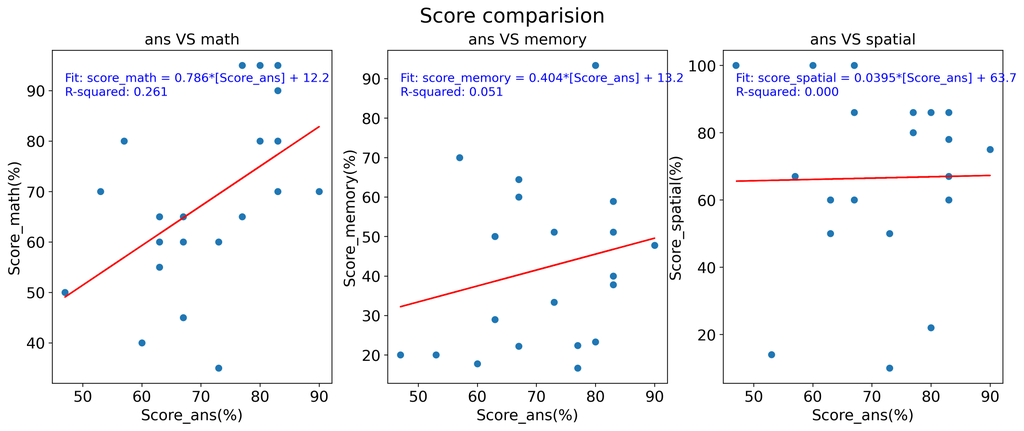

```python
def scatter_plot_comparison(df, y_column, subtitle):
   #plot dots
    plt.scatter(df_result1['score_ans'], df[y_column])
    plt.title(subtitle,fontsize=15)
    plt.xlabel('Score_ans(%)',fontsize = 15)
    plt.ylabel(f'{y_column.capitalize()}(%)',fontsize = 15)
    plt.xticks(fontsize=15)
    plt.yticks(fontsize=15)

    #draw the best fit line
    x = df['score_ans']
    y = df[y_column]
    coefficients = np.polyfit(x, y, 1)
    poly = np.poly1d(coefficients)
    plt.plot(x, poly(x), color='red')

    #label of best fit line and r_squared value
    (slope, intercept, rvalue, pvalue, stderr) = linregress(df_result1['score_ans'], df[y_column])
    text_position = (min(x), max(y) - 0.1 * (max(y) - min(y)))
    r_squared = rvalue**2
    plt.text(text_position[0], text_position[1],f"Fit: {y_column} = {slope:.3g}*[Score_ans] + {intercept:.3g}\nR-squared: {r_squared:.3f}",fontsize=12,color='blue')

#set title and figure size
plt.figure(figsize=(17, 6))
plt.suptitle('Score comparision', fontsize=20)

#plot subplots
plt.subplot(1, 3, 1)
scatter_plot_comparison(df_result1, 'score_math', 'ans VS math')

plt.subplot(1, 3, 2)
scatter_plot_comparison(df_result1, 'score_memory', 'ans VS memory')

plt.subplot(1, 3, 3)
scatter_plot_comparison(df_result1, 'score_spatial', 'ans VS spatial')
```

Figure 3: Scatter graphs illustrating the relationship between marks in ANS and three other tests

```python
#show null hypothesis
print("The null hypothes is there is no relationship between 2 covariants\n")
print("\n************ Spearman Order-ranked Results ************\n")

# calculate correlation for each test
columns_for_correlation = ['score_math', 'score_memory', 'score_spatial']
correlation_results = pd.DataFrame(index=['ANS vs score_math', 'ANS vs score_memory', 'ANS vs score_spatial'], columns=['Correlation', 'P-value', 'Hypothesis'])

#calculate p-value and reject/failed reject null hypothesis
for column in columns_for_correlation:
    correlation, p_value = spearmanr(df_result1['score_ans'], df_result1[column])
    null_hypothesis = 'Reject' if p_value < 0.05 else 'Failed to Reject'
    correlation_results.loc[f'ANS vs {column}'] = [correlation, p_value, null_hypothesis]
    correlation_results = correlation_results.rename(columns={'Hypothesis': 'null_hypothesis(a=0.05)'})

print(correlation_results)
```

```
The null hypothes is there is no relationship between 2 covariants


************ Spearman Order-ranked Results ************

                     Correlation   P-value null_hypothesis(a=0.05)
ANS vs score_math       0.558736  0.008468                  Reject
ANS vs score_memory     0.232334  0.310846        Failed to Reject
ANS vs score_spatial    0.020442  0.929917        Failed to Reject
```

**Below, manual calculation** of Spearman correlation coefficients (r) reinforces these findings: ANS correlates strongest with math (r = 0.57), followed by memory (r = 0.24) and spatial (r = 0.04).

```python
# manually calculation of spearman order test
df_ans_vs_math = pd.read_csv('ans_vs_math.csv')
df_ans_vs_memory = pd.read_csv('ans_vs_memory.csv')
df_ans_vs_spatial = pd.read_csv('ans_vs_spatial.csv')
df_ans_vs_math

#display datafram
def display_dataframe_and_rs(dataframe):
    # Display the DataFrame
    display(dataframe)

    # Extract the "rs" value
    rs_value = dataframe.iloc[-1, -1]

    # Print the "rs" value
    display(Markdown(f"Spearman Correlation Coefficient is {rs_value}"))
```

```python
display_dataframe_and_rs(df_ans_vs_math)
```

|  | score_ans | order | score_math | Order | d_value | d_square | Unnamed: 6 |
| --- | --- | --- | --- | --- | --- | --- | --- |
| 0 | 73.0 | 11.5 | 35.0 | 1.0 | 10.5 | 110.25 | NaN |
| 1 | 67.0 | 9.0 | 65.0 | 10.0 | -1.0 | 1.00 | NaN |
| 2 | 90.0 | 21.0 | 70.0 | 13.0 | 8.0 | 64.00 | NaN |
| 3 | 63.0 | 6.0 | 65.0 | 10.0 | -4.0 | 16.00 | NaN |
| 4 | 80.0 | 15.5 | 80.0 | 16.0 | -0.5 | 0.25 | NaN |
| 5 | 83.0 | 18.5 | 95.0 | 20.0 | -1.5 | 2.25 | NaN |
| 6 | 83.0 | 18.5 | 80.0 | 16.0 | 2.5 | 6.25 | NaN |
| 7 | 73.0 | 11.5 | 60.0 | 7.0 | 4.5 | 20.25 | NaN |
| 8 | 83.0 | 18.5 | 70.0 | 13.0 | 5.5 | 30.25 | NaN |
| 9 | 77.0 | 13.5 | 65.0 | 10.0 | 3.5 | 12.25 | NaN |
| 10 | 67.0 | 9.0 | 45.0 | 3.0 | 6.0 | 36.00 | NaN |
| 11 | 53.0 | 2.0 | 70.0 | 13.0 | -11.0 | 121.00 | NaN |
| 12 | 57.0 | 3.0 | 80.0 | 16.0 | -13.0 | 169.00 | NaN |
| 13 | 47.0 | 1.0 | 50.0 | 4.0 | -3.0 | 9.00 | NaN |
| 14 | 60.0 | 4.0 | 40.0 | 2.0 | 2.0 | 4.00 | NaN |
| 15 | 67.0 | 9.0 | 60.0 | 7.0 | 2.0 | 4.00 | NaN |
| 16 | 80.0 | 15.5 | 95.0 | 20.0 | -4.5 | 20.25 | NaN |
| 17 | 83.0 | 18.5 | 90.0 | 18.0 | 0.5 | 0.25 | NaN |
| 18 | 63.0 | 6.0 | 55.0 | 5.0 | 1.0 | 1.00 | NaN |
| 19 | 63.0 | 6.0 | 60.0 | 7.0 | -1.0 | 1.00 | NaN |
| 20 | 77.0 | 13.5 | 95.0 | 20.0 | -6.5 | 42.25 | NaN |
| 21 | NaN | NaN | NaN | NaN | NaN | 670.50 | rs=0.565 |

Spearman Correlation Coefficient is rs=0.565

```python
display_dataframe_and_rs(df_ans_vs_memory)
```

|  | score_ans | order | score_memory | order.1 | d_value | d_square | Unnamed: 6 |
| --- | --- | --- | --- | --- | --- | --- | --- |
| 0 | 73.0 | 11.5 | 33.33 | 9.0 | 2.5 | 6.25 | NaN |
| 1 | 67.0 | 9.0 | 22.22 | 5.0 | 4.0 | 16.00 | NaN |
| 2 | 90.0 | 21.0 | 47.78 | 12.0 | 9.0 | 81.00 | NaN |
| 3 | 63.0 | 6.0 | 50.00 | 13.5 | -7.5 | 56.25 | NaN |
| 4 | 80.0 | 15.5 | 23.33 | 7.0 | 8.5 | 72.25 | NaN |
| 5 | 83.0 | 18.5 | 58.89 | 17.0 | 1.5 | 2.25 | NaN |
| 6 | 83.0 | 18.5 | 51.11 | 15.5 | 3.0 | 9.00 | NaN |
| 7 | 73.0 | 11.5 | 51.11 | 15.5 | -4.0 | 16.00 | NaN |
| 8 | 83.0 | 18.5 | 37.78 | 10.0 | 8.5 | 72.25 | NaN |
| 9 | 77.0 | 13.5 | 16.67 | 1.0 | 12.5 | 156.25 | NaN |
| 10 | 67.0 | 9.0 | 64.44 | 19.0 | -10.0 | 100.00 | NaN |
| 11 | 53.0 | 2.0 | 20.00 | 3.5 | -1.5 | 2.25 | NaN |
| 12 | 57.0 | 3.0 | 70.00 | 20.0 | -17.0 | 289.00 | NaN |
| 13 | 47.0 | 1.0 | 20.00 | 3.5 | -2.5 | 6.25 | NaN |
| 14 | 60.0 | 4.0 | 17.78 | 2.0 | 2.0 | 4.00 | NaN |
| 15 | 67.0 | 9.0 | 60.00 | 18.0 | -9.0 | 81.00 | NaN |
| 16 | 80.0 | 15.5 | 93.33 | 21.0 | -5.5 | 30.25 | NaN |
| 17 | 83.0 | 18.5 | 40.00 | 11.0 | 7.5 | 56.25 | NaN |
| 18 | 63.0 | 6.0 | 29.00 | 8.0 | -2.0 | 4.00 | NaN |
| 19 | 63.0 | 6.0 | 50.00 | 13.5 | -7.5 | 56.25 | NaN |
| 20 | 77.0 | 13.5 | 22.40 | 6.0 | 7.5 | 56.25 | NaN |
| 21 | NaN | NaN | NaN | NaN | NaN | 1173.00 | rs= 0.238 |

Spearman Correlation Coefficient is rs= 0.238

```python
display_dataframe_and_rs(df_ans_vs_spatial)
```

|  | score_ans | order | score_spatial | Order | d_value | d_square | Unnamed: 6 |
| --- | --- | --- | --- | --- | --- | --- | --- |
| 0 | 73.0 | 11.5 | 10.000000 | 1.0 | 10.5 | 110.25 | NaN |
| 1 | 67.0 | 9.0 | 85.714286 | 16.5 | -7.5 | 56.25 | NaN |
| 2 | 90.0 | 21.0 | 75.000000 | 12.0 | 9.0 | 81.00 | NaN |
| 3 | 63.0 | 6.0 | 60.000000 | 7.5 | -1.5 | 2.25 | NaN |
| 4 | 80.0 | 15.5 | 85.714286 | 16.5 | -1.0 | 1.00 | NaN |
| 5 | 83.0 | 18.5 | 60.000000 | 7.5 | 11.0 | 121.00 | NaN |
| 6 | 83.0 | 18.5 | 66.666667 | 10.5 | 8.0 | 64.00 | NaN |
| 7 | 73.0 | 11.5 | 50.000000 | 4.5 | 7.0 | 49.00 | NaN |
| 8 | 83.0 | 18.5 | 77.777778 | 13.0 | 5.5 | 30.25 | NaN |
| 9 | 77.0 | 13.5 | 80.000000 | 14.0 | -0.5 | 0.25 | NaN |
| 10 | 67.0 | 9.0 | 60.000000 | 7.5 | 1.5 | 2.25 | NaN |
| 11 | 53.0 | 2.0 | 14.285714 | 2.0 | 0.0 | 0.00 | NaN |
| 12 | 57.0 | 3.0 | 66.666667 | 10.5 | -7.5 | 56.25 | NaN |
| 13 | 47.0 | 1.0 | 100.000000 | 20.0 | -19.0 | 361.00 | NaN |
| 14 | 60.0 | 4.0 | 100.000000 | 20.0 | -16.0 | 256.00 | NaN |
| 15 | 67.0 | 9.0 | 100.000000 | 20.0 | -11.0 | 121.00 | NaN |
| 16 | 80.0 | 15.5 | 22.222222 | 3.0 | 12.5 | 156.25 | NaN |
| 17 | 83.0 | 18.5 | 85.714286 | 16.5 | 2.0 | 4.00 | NaN |
| 18 | 63.0 | 6.0 | 50.000000 | 4.5 | 1.5 | 2.25 | NaN |
| 19 | 63.0 | 6.0 | 60.000000 | 7.5 | -1.5 | 2.25 | NaN |
| 20 | 77.0 | 13.5 | 85.714286 | 16.5 | -3.0 | 9.00 | NaN |
| 21 | NaN | NaN | NaN | NaN | NaN | 1485.50 | rs = 0.0354 |

Spearman Correlation Coefficient is rs = 0.0354

**In conclusion, the results from three different statistical methods suggest a correlation between maths and ANS performance. Conversey, there is insufficient evidence to support the correlation between ANS and the other two tests.

### 3.2 Hypothesis B: Can we detect the difference between scores based on gender?

To investigate this hypothesis, overlapped samples need to be further classified based on their gender (see below).

```python
#hypothesis B

#group data in male and female
grouped_by_gender = df_result1.groupby('gender')
df_male = grouped_by_gender.get_group('male').reset_index(drop=True)
df_female = grouped_by_gender.get_group('female').reset_index(drop=True)

display(Markdown("### Male Table"))
display(df_male)

display(Markdown("### Female Table"))
display(df_female)
```

Male Table

|  | user_id | age | gender | score_ans | score_math | score_spatial | score_memory |
| --- | --- | --- | --- | --- | --- | --- | --- |
| 0 | MCHC | 19 | male | 67 | 65 | 86 | 22.22 |
| 1 | FZHF | 19 | male | 80 | 80 | 86 | 23.33 |
| 2 | RHJM | 20 | male | 83 | 95 | 60 | 58.89 |
| 3 | HAHA | 20 | male | 83 | 80 | 67 | 51.11 |
| 4 | FWNO | 20 | male | 73 | 60 | 50 | 51.11 |
| 5 | ABAB | 20 | male | 83 | 70 | 78 | 37.78 |
| 6 | KKXX | 20 | male | 67 | 45 | 60 | 64.44 |
| 7 | CNDB | 18 | male | 53 | 70 | 14 | 20.00 |
| 8 | FGFG | 20 | male | 57 | 80 | 67 | 70.00 |
| 9 | TRLO | 20 | male | 47 | 50 | 100 | 20.00 |
| 10 | XTTR | 21 | male | 60 | 40 | 100 | 17.78 |
| 11 | PENG | 22 | male | 80 | 95 | 22 | 93.33 |
| 12 | TTTT | 20 | male | 83 | 90 | 86 | 40.00 |
| 13 | QQQQ | 20 | male | 63 | 60 | 60 | 50.00 |
| 14 | DXEW | 20 | male | 77 | 95 | 86 | 22.40 |

Female Table

|  | user_id | age | gender | score_ans | score_math | score_spatial | score_memory |
| --- | --- | --- | --- | --- | --- | --- | --- |
| 0 | VGAT | 21 | female | 73 | 35 | 10 | 33.33 |
| 1 | YCBH | 20 | female | 90 | 70 | 75 | 47.78 |
| 2 | CTCT | 21 | female | 63 | 65 | 60 | 50.00 |
| 3 | WWWW | 18 | female | 77 | 65 | 80 | 16.67 |
| 4 | WYCM | 25 | female | 67 | 60 | 100 | 60.00 |
| 5 | ZQTC | 54 | female | 63 | 55 | 50 | 29.00 |

Box plots below (Figure 4) are employed to draw conclusions regarding performance differences based on gender. **In this analysis, all four test boxes exhibit overlap, indicating no substantial gender-based differences in performance.**

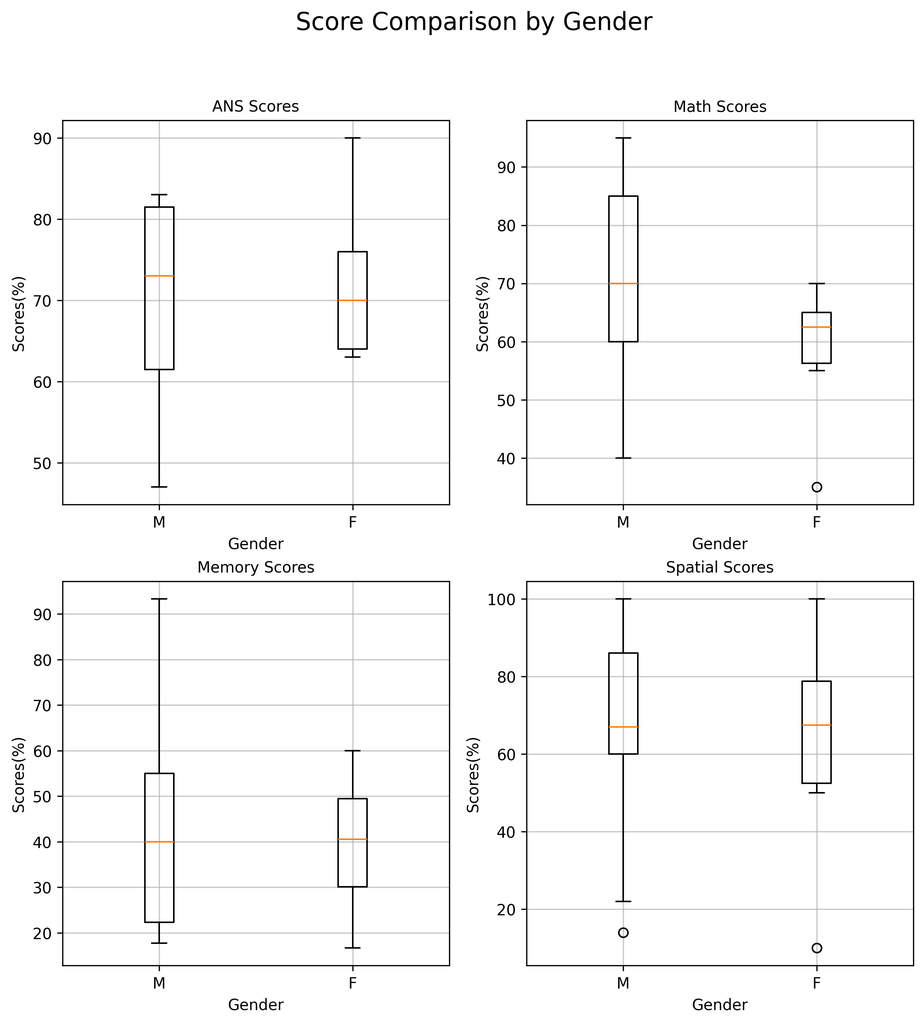

Figure4: Box plots demonstrating performance difference in the four tests based on gender difference

```python
def plot_boxplot(df_male, df_female, score_column, subplot_index, subplot_title):
    #plot dots
    plt.subplot(2, 2, subplot_index)
    plt.boxplot([df_male[score_column], df_female[score_column]], labels=['M', 'F'])
    plt.title(subplot_title)
    plt.xlabel('Gender')
    plt.ylabel('Scores(%)')
    plt.grid(True, linestyle='-', alpha=0.7)

#set title and figure size
fig = plt.figure(figsize=(10, 10))
fig.suptitle('Score Comparison by Gender', fontsize=16)

#plot subplots
plot_boxplot(df_male, df_female, 'score_ans', 1, 'ANS Scores')
plot_boxplot(df_male, df_female, 'score_math', 2, 'Math Scores')
plot_boxplot(df_male, df_female, 'score_memory', 3, 'Memory Scores')
plot_boxplot(df_male, df_female, 'score_spatial', 4, 'Spatial Scores')

# To display figure with caption
caption = "Figure4: Box plots demonstrating performance difference in the four tests based on gender difference"

display_figure(fig, "fig4", caption, 0.8, 10)
```

```python
# Specify the columns for t-test
columns_for_ttest = ['score_ans', 'score_math', 'score_spatial', 'score_memory']

# Create an empty DataFrame to store t-test results
ttest_results = pd.DataFrame(index=columns_for_ttest, columns=['Mean_Male', 'SE_Male', 'Mean_Female', 'SE_Female', 'Difference', 'P-value'])

# Perform t-test for each test
for column in columns_for_ttest:

    # Extract scores for male and female
    scores_male = df_male[column]
    scores_female = df_female[column]

    # Perform t-test assuming equal variance
    t_statistic, p_value = ttest_ind(scores_male, scores_female, equal_var=True)

    # Calculate means and standard errors
    mean_male, mean_female = scores_male.mean(), scores_female.mean()
    se_male, se_female = scores_male.sem(), scores_female.sem()

    # Calculate difference in means
    diff_means = mean_male - mean_female

    # Update the summary DataFrame
    ttest_results.loc[column] = [mean_male, se_male, mean_female, se_female, diff_means, p_value]

# Display the t-test results
print("\n************ T-Test Results ************\n")
print(ttest_results)
```

```
************ T-Test Results ************

               Mean_Male   SE_Male Mean_Female SE_Female Difference   P-value
score_ans           70.4  3.151417   72.166667  4.230183  -1.766667  0.758956
score_math     71.666667  4.722456   58.333333  5.109903  13.333333  0.120145
score_spatial  68.133333  6.544257        62.5  12.63263   5.633333  0.669875
score_memory      42.826  5.825943   39.463333  6.502764   3.362667  0.744154
```

The graphs of the t-test (Figure 5) produce analysis with annotated mean and error bars. From these graphs, we can see there is **no significant difference** in mean score based on gender in ANS, memory and spatial tests, as there are overlaps between the error bars in these tests. For the maths test, the big difference in mean score (13.33) makes no overlap between error bars. However, this difference is **not significant enough to reject the null hypothesis above.**

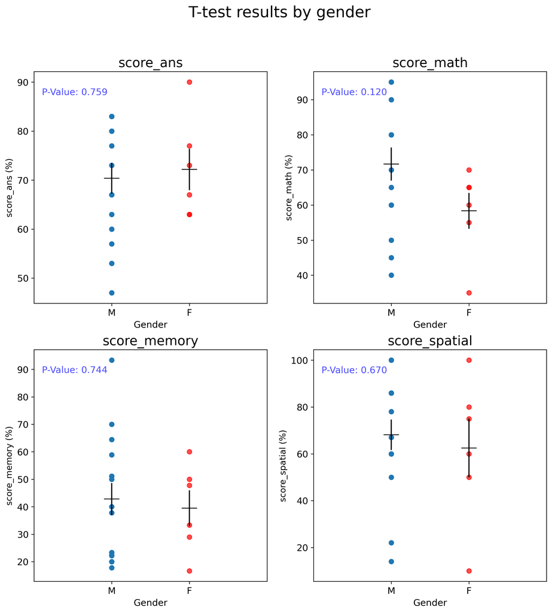

```python
def plot_gender_comparison(df, ttest_results, columns_for_ttest):

    # Create subplots
    fig, axes = plt.subplots(nrows=2, ncols=2, figsize=(12, 12))
    axes = axes.flatten()

    # Plot for each score type
    for i, column in enumerate(columns_for_ttest):
        ax = axes[i]
        ax.set_xlim(0,3)
        x_male = 1.0
        x_female = 2

        # Extract t-test results and data
        mean_male = ttest_results.loc[column, 'Mean_Male']
        se_male = ttest_results.loc[column, 'SE_Male']
        mean_female = ttest_results.loc[column, 'Mean_Female']
        se_female = ttest_results.loc[column, 'SE_Female']
        scores_male = df[df['gender'] == 'male'][column]
        scores_female = df[df['gender'] == 'female'][column]
        p_value = ttest_results.loc[column, 'P-value']

        # Plot individual data points
        ax.plot(np.full_like(scores_male, x_male), scores_male, 'o',  label='Male')
        ax.plot(np.full_like(scores_female, x_female), scores_female, 'o', color='red', alpha=0.7, label='Female')

        # Plot means with error bars
        ax.errorbar(x_male, mean_male, yerr=se_male, marker='_', color='black', markersize=20, label='Mean ± SE (Male)')
        ax.errorbar(x_female, mean_female, yerr=se_female, marker='_', color='black', markersize=20)

        # Display p-value in the subplot
        ax.text(0.1, ax.get_ylim()[1] - 0.1 * (ax.get_ylim()[1] - ax.get_ylim()[0]), f'P-Value: {p_value:.3f}', fontsize=12, color='blue', alpha=0.7)

        # Adjust x-axis and y-axis ticks, labels and titles
        fig.suptitle('T-test results by gender ', fontsize=20)
        ax.set_title(f'{column}',fontsize=17)
        ax.set_xlabel('Gender',fontsize=12)
        ax.set_ylabel(f'{column} (%)', fontsize=11)
        ax.set_xticks([x_male, x_female])
        ax.set_xticklabels(['M', 'F'],fontsize=10)
        ax.tick_params(axis='y', labelsize=12)
        ax.tick_params(axis='x', labelsize=12)



# Replace it with actual variable
columns_for_ttest = ['score_ans', 'score_math', 'score_memory', 'score_spatial']
plot_gender_comparison(df_result1,  ttest_results, columns_for_ttest)
```

Figure5: T test graphs annotated with means and error bars, demonstrating the relationship between the score(%) and the gender

**Overall, from these three sets of figures, we concluded there is no difference in the performance between males and females across all 4 tests.**

### 3.3 Extensional Research Towards ANS

#### 3.3.1 Effect of drinks on ANS

Besides the two hypotheses, we were also interested in **how different drinks might affect ANS performance.** We asked participants about the drinks they consumed before the test, including alcoholic drinks, coffee/energy drinks, or nothing at all. **Our expectation was that alcoholic drinks might negatively impact performance, leading to lower scores, while coffee/energy drinks might have the opposite effect.** In the table that records self-reported data on the ANS study, the "drink" column uses codes: "a" for coffee/energy drinks, "b" for alcohol, and "c" for no drink. For instance, the absence of "b" means that the individual did not report consume alcohol before the test.

```python
#group data in drink or no drink
grouped_by_drink = df_analysis.groupby('drink')
df_a = grouped_by_drink.get_group('a').reset_index(drop=True)
df_c = grouped_by_drink.get_group('c').reset_index(drop=True)

display(Markdown("### drink coffee/energy drink"))
display(df_a)

display(Markdown("### No drink"))
display(df_c)
```

drink coffee/energy drink

|  | user_id | age | gender | drink | score | sum_first_10 | sum_second_10 | sum_last_10 |
| --- | --- | --- | --- | --- | --- | --- | --- | --- |
| 0 | CAJA | 20 | female | a | 63 | 9 | 6 | 4 |
| 1 | VGAT | 21 | female | a | 73 | 10 | 7 | 5 |
| 2 | MCHC | 19 | male | a | 67 | 7 | 3 | 10 |
| 3 | KYJS | 19 | female | a | 90 | 10 | 8 | 9 |
| 4 | RYJC | 19 | male | a | 87 | 10 | 7 | 9 |
| 5 | ARKK | 21 | male | a | 80 | 8 | 6 | 10 |
| 6 | JCBC | 19 | male | a | 83 | 9 | 6 | 10 |
| 7 | FWNO | 20 | male | a | 73 | 7 | 6 | 9 |
| 8 | CLTC | 21 | male | a | 77 | 8 | 6 | 9 |
| 9 | PENG | 22 | male | a | 80 | 9 | 7 | 8 |
| 10 | IVAN | 21 | male | a | 67 | 6 | 5 | 9 |
| 11 | GYSJ | 10 | male | a | 83 | 8 | 8 | 9 |
| 12 | DXEW | 20 | male | a | 77 | 8 | 7 | 8 |
| 13 | ABCD | 13 | male | a | 53 | 8 | 2 | 6 |

No drink

|  | user_id | age | gender | drink | score | sum_first_10 | sum_second_10 | sum_last_10 |
| --- | --- | --- | --- | --- | --- | --- | --- | --- |
| 0 | RTDS | 19 | female | c | 67 | 8 | 4 | 8 |
| 1 | KLPB | 18 | male | c | 77 | 10 | 5 | 8 |
| 2 | YKJL | 21 | female | c | 87 | 9 | 9 | 8 |
| 3 | CYNT | 20 | female | c | 90 | 10 | 9 | 8 |
| 4 | YCBH | 20 | female | c | 90 | 10 | 7 | 10 |
| 5 | CTCT | 21 | female | c | 63 | 8 | 7 | 4 |
| 6 | LQEG | 20 | female | c | 77 | 7 | 8 | 8 |
| 7 | DATO | 28 | male | c | 83 | 8 | 10 | 7 |
| 8 | FZHF | 19 | male | c | 80 | 9 | 6 | 9 |
| 9 | RHJM | 20 | male | c | 83 | 8 | 8 | 9 |
| 10 | HAHA | 20 | male | c | 83 | 9 | 8 | 8 |
| 11 | SKHJ | 19 | female | c | 77 | 6 | 9 | 8 |
| 12 | ABAB | 20 | male | c | 83 | 8 | 8 | 9 |
| 13 | WWWW | 18 | female | c | 77 | 8 | 8 | 7 |
| 14 | KKXX | 20 | male | c | 67 | 7 | 5 | 8 |
| 15 | CNDB | 18 | male | c | 53 | 7 | 3 | 6 |
| 16 | FGFG | 20 | male | c | 57 | 5 | 7 | 5 |
| 17 | CJTY | 21 | male | c | 57 | 6 | 7 | 4 |
| 18 | TRLO | 20 | male | c | 47 | 6 | 5 | 3 |
| 19 | XTTR | 21 | male | c | 60 | 6 | 4 | 8 |
| 20 | JCPB | 19 | male | c | 30 | 9 | 0 | 0 |
| 21 | YXTH | 21 | female | c | 63 | 9 | 4 | 6 |
| 22 | BWHA | 23 | male | c | 50 | 7 | 6 | 2 |
| 23 | SWRA | 19 | male | c | 77 | 8 | 5 | 10 |
| 24 | JUVE | 20 | male | c | 83 | 10 | 6 | 9 |
| 25 | XIED | 20 | male | c | 87 | 8 | 8 | 10 |
| 26 | WYCM | 25 | female | c | 67 | 5 | 7 | 8 |
| 27 | DXTC | 20 | female | c | 63 | 7 | 6 | 6 |
| 28 | DSGC | 44 | male | c | 50 | 7 | 7 | 1 |
| 29 | HJJ1 | 20 | man | c | 57 | 7 | 5 | 5 |
| 30 | TTTT | 20 | male | c | 83 | 7 | 8 | 10 |
| 31 | YAGE | 20 | female | c | 73 | 7 | 7 | 8 |
| 32 | ZHOU | 28 | female | c | 77 | 6 | 8 | 9 |
| 33 | ZQTC | 54 | female | c | 63 | 6 | 9 | 4 |
| 34 | QQQQ | 20 | male | c | 63 | 8 | 2 | 9 |

Analyzing the 'score comparison by drink' graph reveals an overall overlap in the box plots （Figure 6) of the 'coffee' and 'neither' groups. This suggests no significant differences in performance between the two groups. However, it's worth noting that the median score of the 'neither' group is slightly lower than that of the 'coffee' group. Additionally, the range of scores in the 'neither' group is considerably larger than that in the 'coffee' group. **These findings suggest that, with respect to central values, participants who drank coffee performed slightly better than those who did not.**

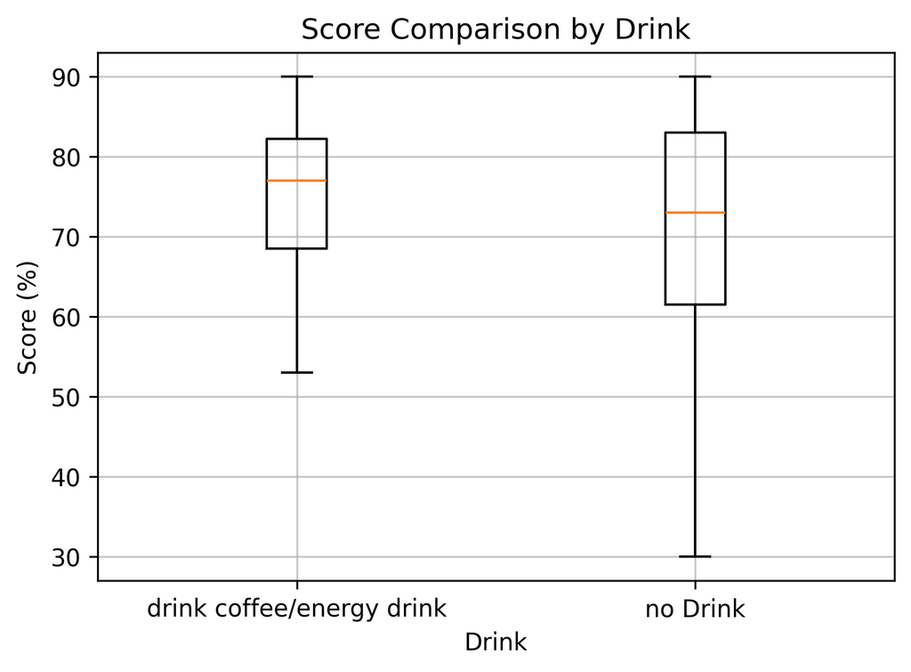

```python
def draw_box_plot(data, labels, xlabel, ylabel, title):
    #plot dots and set labels
    plt.figure(figsize=(6, 4))
    plt.boxplot(data, labels=labels)
    plt.xlabel(xlabel)
    plt.ylabel(f'{ylabel} (%)')
    plt.title(title)
    plt.grid(True, linestyle='-', alpha=0.7)
    plt.show()

# score comparison by drink
data_drink = df_analysis[df_analysis['drink'] == 'a']['score']
data_no_drink = df_analysis[df_analysis['drink'] == 'c']['score']
draw_box_plot([data_drink, data_no_drink], ['drink coffee/energy drink', 'no Drink'], 'Drink', 'Score', 'Score Comparison by Drink')
```

Figure 6: box plots comparing the score distribution of drink coffe/energy drink and no drink

#### 3.3.2 Effect of different ANS test mode/categories on performance

ANS tests were designed to incorporate different difficulty levels, and the tests are divided into three categories: ratio, density, and size of dots, with 10 tests in each. We maintained a fixed ratio with an increasing trend across each section (e.g., 3:4, 6:7, 7:8, 8:9 to 9:10). Additionally, the number of dots for each ratio is consistent; for instance, if the first test in the first section is 9:12, the first test in the second section is also 9:12. However, the arrangement and size of dots may vary.

This study aims to find whether different categories of ANS have different effects on ANS scores. If so, what are they? Analyzing the "Score Comparison by Categories" box plot (Figure 7) reveals some overlap among all three data groups, indicating no significant differences between different interpretations. However, the 'ratio' category exhibits a smaller data range than the other two categories, suggesting that interpretation variations do impact scores, particularly in ratio. The 'density' category stands out with the smallest median score, suggesting that **differences in dot density may influence participants more significantly than the other categories.**

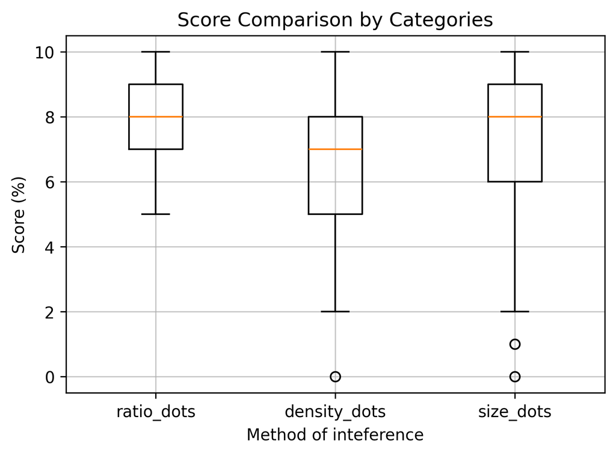

```python
# score comparison by three parts:ratio,density,size
data_categories = [df_analysis['sum_first_10'], df_analysis['sum_second_10'], df_analysis['sum_last_10']]
draw_box_plot(data_categories, ['ratio_dots', 'density_dots', 'size_dots'], 'Method of inteference', 'Score', 'Score Comparison by Categories')
```

Figure 7: Box plots demonstrating score distribution for each ANS category

### 3.4 Relation with current research findings

Considering **hypothesis A**, a current theory posits that the relationship between ANS and maths ability unfolds over time. Also, the ANS plays a role in the gradual development of advanced numerical skills, ultimately activating the same brain region associated with mathematical processing Piazza et al. (2006).**It aligns with our conclusion that there is a positive correlation between maths and ANS. But there is less evidence confirming the relationship between ANS and other two abilities.** Considering **hypothesis B**, there have been stereotypes of girls with weaker maths ability and this might hinder their intuitive sense of numbers. This hindrance could potentially impact their grasp of formal mathematical concepts and influence their interest in mathematics related field. As a result, they performed worse in ANS and maths tests than boys Stoet et al. (2013).**Our conclusion that there is no gender difference across the four abilities did not correspond with that piece of findings.** However, Since we used **much smaller sample size than their research (762 boys and girls)**, our result is **not sufficient to challenge theirs.** Additionally, our study examines participants' ability by comparing the scores. Nevertheless, we could have also considered the time taken by participants. Since there are possibly time-mark trade-off decisions made by them, this could influence their performances. Such method has been named as **diffusion model** which takes both accuracy and reaction time into account Park et al. (2015).

### 3.5 Critical Evaluation and How to Improve

Additionally, the maths test did not upload the time taken for completion to the google form. We were aware of this omission after the collection process ended. This could only be prevented by remembering checking the dictionary before the data collection.

In terms of test design, we did not implement measures to mitigate random errors. For example, users inadvertently pressed the wrong button despite knowing the correct answer. A more effective approach would allow test takers to attempt the test multiple times, with each attempt featuring different pattern of questions. This repetition serves to eliminate random errors over multiple trials, enhancing the reliability of the test resultsLin et al. (2015).

In the future when we gather more data, our intention is to develop a linear regression model that can predict ANS scores based on various influencing factors. The model is conceptualized as follows:

$ ANS score=β0 +β1 ×Gender+β2 ×Age+β3 ×Maths Score+β4 ×Memory Score+ $

$ β5 ×Spatial Reasoning Score+β6 ×Background+β7 ×Family Influence+β8 ×TypeA Drink+β9 ×TypeB Drink+ϵ $

In this expanded model, β0 represents the intercept, β1 to β9 are coefficients for each predictor variable. Gender, Background, Family Influence, TypeA Drink, and TypeB Drink are categorical variables. These will be represented in the model using dummy variables. Similarly, Age, Maths Score, Memory Score, and Spatial Reasoning Score are numerical predictors. Besides, ϵ represents the error term, capturing the variance in ANS scores not explained by the predictors.

Firstly, we plan to convert categorical variables into dummy variables to facilitate inclusion in the regression model. Secondly, t-tests will be used to assess the significance of each predictor, indicated by p-values. Variables with high p-values might be less significant and could be candidates for removal. Thirdly, we will utilize R-squared and Adjusted R-squared values to examine how well the model explains the variability in ANS scores. Fourthly, we would like to perform residual analysis to ensure residuals are normally distributed, exhibit homoscedasticity, and maintain independence. Finally, we plan to split the data into training and testing sets to evaluate the model's predictive power on unseen data.

## 4. Summary and outlook:

While our study supports existing research on the positive correlation between ANS and math, caution is needed due to limited evidence regarding ANS relationships with memory and spatial abilities. No significant gender differences were found across the four abilities.

The visual cortex has an impact on ANS, previous research has highlighted the role of the visual cortex in processing numerical information via the ANS. The intraparietal region, which helps perceive numbers, depends on the primary cortex to filter out irrelevant details like the size or shape of objects. This understanding paves the way for future studies to explore how different visual setups, like how objects are arranged, affect our ability to estimate numbers. These findings could help create better tools for learning numbers that are based on visual methods.

The correlation between ANS sharpness in early childhood and later mathematical achievement was shown to be a profound finding. This connection opens possibilities for future longitudinal studies that track ANS development from infancy through formal education years, providing valuable insights into cognitive development. Investigating how early ANS precision predicts future maths performance can guide educational interventions, particularly for children at risk of arithmetic difficulties.

There are applications in society and classroom implications. Understanding the impact of ANS on learning can significantly influence teaching methods. Future research should focus on evaluating and refining educational tools that utilize the strength of ANS, like counting games. Emphasis should be on early childhood education, especially for children from disadvantaged backgrounds, to strengthen their numerical abilities. Also, longitudinal studies should be conducted to understand how early ANS development influences later academic success, in mathematics and perhaps sciences. Besides, developing and testing new educational technologies and games could enhance ANS skills in children. Finally, it would be worth expanding research to diverse demographics to understand cultural and socio-economic influences on ANS development and mathematical performance.

Overall, the potential of continuing research in the field of ANS and its relationships with cognitive abilities is immense. Not only does it hold promise for advancing understanding of cognitive neuroscience, but it also has practical implications for educational strategies. By investing in and exploring this research area, we can pave the way for innovative educational methods, tailored to various learning needs and backgrounds, eventually contributing to more effective and inclusive educational practices.

## 5. Bibliography

[Mazzocco, M.M.M., Feigenson, L. and Halberda, J. (2011)](https://doi.org/10.1371/journal.pone.0023749) Approximate Number System Predicts Later School Mathematics Performance. PLoS ONE, 6(9), p.e23749.

[Stoet, G. and Geary, D.C. (2013)](https://doi.org/10.1371/journal.pone.0057988) Sex Differences in Mathematics and Reading Achievement Are Inversely Related: Within- and Across-Nation Assessment of 10 Years of PISA Data. PLoS ONE, 8(3), p.e57988.

[Pauls, F., Petermann, F. and Lepach, A.C. (2013)](https://doi.org/10.1080/09658211.2013.765892) Gender differences in episodic memory and visual working memory including the effects of age. Memory, 21(7), pp.857–874.

[Piazza, M., Pinel, P., Le Bihan, D. and Dehaene, S. (2007)](https://doi.org/10.1016/j.neuron.2006.11.022) A Magnitude Code Common to Numerosities and Number Symbols in Human Intraparietal Cortex. Neuron, 53(2), pp.293–305.

[Stoet, G. and Geary, D.C. (2013)](https://doi.org/10.1371/journal.pone.0057988) Sex Differences in Mathematics and Reading Achievement Are Inversely Related: Within- and Across-Nation Assessment of 10 Years of PISA Data. PLoS ONE, 8(3), p.e57988.

[Park, J. and Starns, J.J. (2015)](https://doi.org/10.3389/fpsyg.2015.01955) The Approximate Number System Acuity Redefined: A Diffusion Model Approach. Frontiers in Psychology, 6.

[Lin, Q., Neethling, S.J., Dobson, K.J., Courtois, L. and Lee, P.D. (2015)](https://doi.org/10.1016/j.cageo.2014.12.008.) Quantifying and minimising systematic and random errors in X-ray micro-tomography based volume measurements. Computers & Geosciences, 77, pp.1–7.